# Lab 1: CNN Visualization

## Visualizing convolutional filters from the circuit

The next step would be to analyze the filters that form the input for the chosen filter. To do so, the convolutional layer 'block4_conv2' will be anlyzed. This layer contains information about the incoming activations for filter 196.

```python
# Taking the layer and its weights to analyze incoming activations
filters, biases = model.get_layer('block4_conv2').get_weights()
print("block4_conv2", filters.shape)
```

```
block4_conv2 (3, 3, 512, 512)
```

Taking the L2 norm over all the incoming activations for the unit 196. After getting all the norms, we sorted the results to obtain the filters with the strongest weights. The top 6 strongest will be chosen.

```python
# Array to store the L2 norms of the weights
weights_norm = []
for i in range(512):

    # The norm is taken from each filter that influences on the unit 196
    weights_norm.append(np.linalg.norm(filters[:,:,i,196]))

# List is sorted according to the highest norms
top_six = np.argsort(weights_norm)[-6:]
```

The next figures show the results of the filters by plotting the filter coefficients of the first six. We consider that these will have the most influence on the filter unit 196 because after walking through the 512 filters that influence on the layer and this unit, these 6 filters had the strongest activation because they held the highest absolute values on their coefficients through the norm. This is because the magnitude of the matrix, norm, that makes up the filter is related directly to the strength of the influence of activation of the filter. In this part we do not consider if the filter will be excitatory or inhibitory.

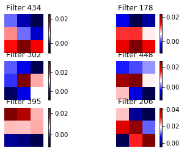

```python
# Plotting of the filters
for i in range(6):
    ax = plt.subplot(3, 2, i+1)
    plt.imshow(filters[:,:,top_six[i],196], cmap='seismic')
    plt.title('Filter '+str(top_six[i]))
    plt.colorbar()
    plt.axis('off')
```

The filter plots can be interpreted by the color: the blue part indicates inhibitions or negative coefficients, while red color indicates the excitations or positive coefficients. These will influece on the filter 196 on the next convolutional layer, the filter that was originaly chosen because their norm are the strongest. To consider the type of influence they will have on the the filter we consider two factors: the amounnt of positive coefficients versus negative coefficients a filter has, and the mean value of the coefficients. In this part we do consider the positive or negative value of the coefficients, hence considering if they are excitatory or inhibitory.

The filters that have a positive mean value and more positive coefficients than negative ones (at least 5 positive coefficients) will be excitatory. Otherwise they will be inhibitory.

```python
for i in top_six:
    # getting a deep copy from one of the top six filters.
    mat = filters[:, :, i, 196].copy()

    # calculating how many positive coefficients are in each filter
    positive_coeffs = len(mat[np.where( mat > 0)])

    # getting the mean value of the filter
    mean_value = mat.mean()

    # printing results
    print("Filter", i ,"had", positive_coeffs, "possitive coefficients.", "Mean Value:",  mean_value)
```

```
Filter 434 had 6 possitive coefficients. Mean Value: 0.006557192
Filter 178 had 6 possitive coefficients. Mean Value: 0.0073837745
Filter 302 had 7 possitive coefficients. Mean Value: 0.0059446497
Filter 448 had 5 possitive coefficients. Mean Value: 0.005343188
Filter 395 had 6 possitive coefficients. Mean Value: 0.00656599
Filter 206 had 7 possitive coefficients. Mean Value: 0.019114725
```

With the results, we can conclude that all the filters are excitatory for the filter 196.

## Maximizing activation on filters

As we did before, the gradient ascent in input space through gradient descent of the excitatory filters will be applied to create an image that will maximally excite each of the filters. This will allow us to consider how these filters form a cirtcuit that can contribute to the detection of certain features.

We use the function that was used in the previous section.

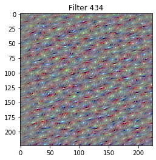

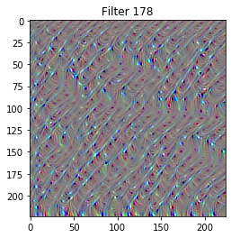

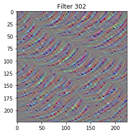

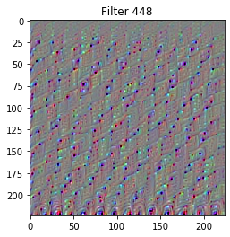

[figure not shown]

[figure not shown]

```python
# Defining the layer of the excitatory filters
layer_name2 = 'block4_conv2'

# The index of the excitatory filters taken from previous section
filter_index2 = top_six

# Using the previous functions
for i in range(6):
    image2 = maximize_filter(layer_name2, filter_index2[i])[0]
    image2 = processing_image(image2)

    # subplotting each filter
    plt.title("Filter " + str(filter_index2[i]))
    plt.imshow(image2, cmap="hsv")
    plt.show()
```

We can try to interpret these results. Taking into account the assumptions made at the beginning of the lab, these filters seem to make a circuit that is excited by features related to curves and textures.

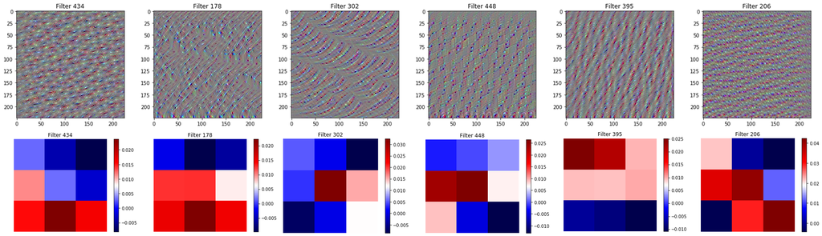

We can visualize the circuit formed for unit 196 through the weights that connect it to the 6 filters that are most influential on it.

The hypothesis was that filter 196 was activated by curves directed toward the lower left corner of an image. The downstream clients of curves are ones that involve curves. [4] In this case, all the top six filters involve them.

Filter 434 is maximally excited by a pattern of small circles, which could be used to detect eyes or coins. Filter 178 is maximally excited by curved lines that stream diagonally. They could most likely detect edges or diagonal compositions, such as lines or structures. Filter 302 is maximally excited by curves facing the lower left corner, but they seem to be more flat than those appeared for filter 196. Filter 448 is maximally excited by rhombuses with round edges. They can resemble holes or images that have dots with high contrast. Filter 395 is maximally excited by lines facing diagonally. They seem rounded, almost like cables. They could detect edges and slight curves on images. Filter 206 is maximally excited by high contrast texture, similar to circular bumps. They could be used to detect contrast patterns in depth or color in an image.

## Conclusion

Overall the circuit can detect curves and edges. It contains filters that detect from curves lines to quarters of circles. This seems to indicate that the circuit will be able to detect curves that are variant in curvature and space.

The filter we originally chose, 196, most likely is part of a larger circuit which can detect position invariant curves and edges, as well as high contrast texture, as shown by the input activations.

## References

1. VGG16 and VGG19. Keras. https://keras.io/api/applications/vgg/
2. 5.4-visualizing-what-convnets-learn.ipynb. F. Chollet. Github Repository. Sept 10, 2017
3. Microscope AI. VGG19 Model. https://microscope.openai.com/models/vgg19_caffe/conv4_2_conv4_2_0/206
4. Olah, et al., "Zoom In: An Introduction to Circuits", Distill, 2020.